# AED Conceitos - Aula 1

## 2.7 Valores incomuns

Outliers são observações incomuns; pontos de dados que não parecem se encaixar no padrão. Às vezes, outliers são erros de entrada de dados; outras vezes, outliers sugerem uma nova ciência importante. Quando você tem muitos dados, às vezes é difícil ver outliers em um histograma. Por exemplo, pegue a distribuição da yvariável do conjunto de dados de diamantes. A única evidência de outliers são os limites incomumente amplos no eixo x.

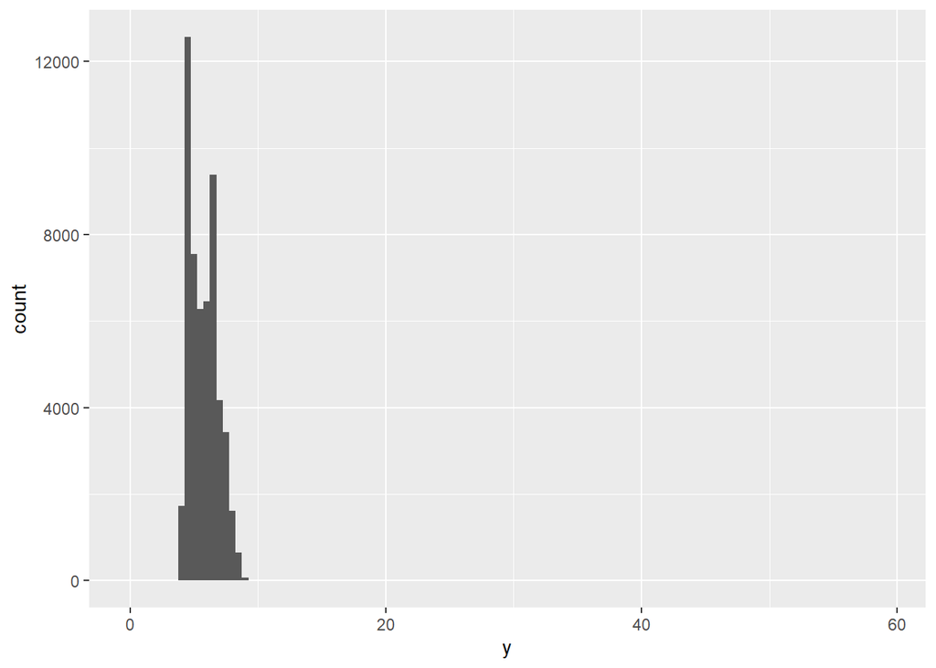

```r
ggplot(diamonds, aes(x = y)) +
  geom_histogram(binwidth = 0.5)
```

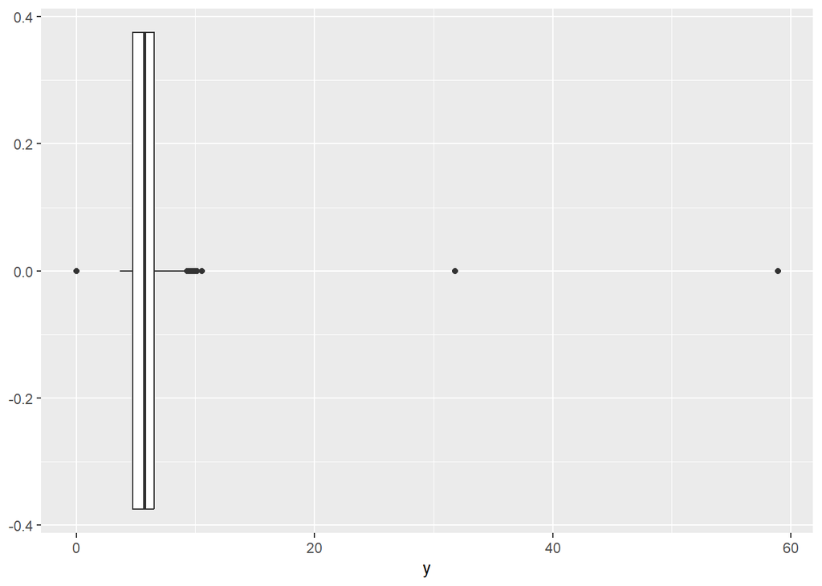

```r
ggplot(diamonds, aes(x = y)) +
  geom_boxplot()
```

É uma boa prática repetir sua análise com e sem os outliers. Se eles tiverem um efeito mínimo nos resultados e você não conseguir descobrir por que eles estão lá, é razoável substituí-los por valores ausentes e seguir em frente. No entanto, se eles tiverem um efeito substancial em seus resultados, você não deve abandoná-los sem justificativa. Você precisará descobrir o que os causou (por exemplo, um erro de entrada de dados).

**Veremos mais sobre o que fazer com esses valores na próxima monitoria**

## 2.8 Valores Ausentes

**Próxima aula (Tratamento de dados)**

# 3 Análise Bivariada

Na análise bivariada procuramos identificar relações entre duas variáveis. Assim como na análise univariada, estas relações podem ser resumidas por gráficos, tabelas e/ou medidas estatísticas. O tipo de resumo vai depender dos tipos das variáveis envolvidas. Vamos considerar três possibilidades:

- Qualitativa vs qualitativa
- Qualitativa vs quantitativa
- Quantitativa vs quantitativa

## 3.1 Qualitativa vs Qualitativa

Vamos considerar as variáveis `Estado.civil` (estado civil), e `Grau.de.Instrução` (grau de instrução). A tabela envolvendo duas variáveis é chamada tabela de cruzamento ou tabela de contingência, e pode ser apresentada de várias formas, conforme discutido a seguir.

A forma mais adequada de apresentação vai depender dos objetivos da análise e da interpretação desejada para os dados. Iniciamente obtemos a tabela de frequências absolutas para o cruzamento das duas variávies, usando a função `table()`.

```r
civ_inst_tb = table(milsa$Estado_Civil, milsa$Grau_Instrucao)
civ_inst_tb
```

```
##
##            ensino fundamental ensino médio superior
##   casado                    5           12        3
##   solteiro                  7            6        3
```

Podemos adicionar os totais:

```r
addmargins(civ_inst_tb)
```

```
##
##            ensino fundamental ensino médio superior Sum
##   casado                    5           12        3  20
##   solteiro                  7            6        3  16
##   Sum                      12           18        6  36
```

Tabelas de frequências relativas são obtidas com prop.table(), mas aqui existem três possibilidades para as proporções em cada casela:

- Em relação ao total geral
- Em relação aos totais por linha (margin = 1)
- Em relação aos totais por coluna (margin = 2)

```r
prop_civ_inst_tb = prop.table(civ_inst_tb)
prop_civ_inst_tb
```

```
##
##            ensino fundamental ensino médio   superior
##   casado           0.13888889   0.33333333 0.08333333
##   solteiro         0.19444444   0.16666667 0.08333333
```

```r
prop_civ_inst_tb = prop.table(civ_inst_tb, margin = 1)
addmargins(prop_civ_inst_tb)
```

```
##
##            ensino fundamental ensino médio superior    Sum
##   casado               0.2500       0.6000   0.1500 1.0000
##   solteiro             0.4375       0.3750   0.1875 1.0000
##   Sum                  0.6875       0.9750   0.3375 2.0000
```

```r
prop_civ_inst_tb = prop.table(civ_inst_tb, margin = 2)
addmargins(prop_civ_inst_tb)
```

```
##
##            ensino fundamental ensino médio  superior       Sum
##   casado            0.4166667    0.6666667 0.5000000 1.5833333
##   solteiro          0.5833333    0.3333333 0.5000000 1.4166667
##   Sum               1.0000000    1.0000000 1.0000000 3.0000000
```

### 3.1.1 Representação Gráfica

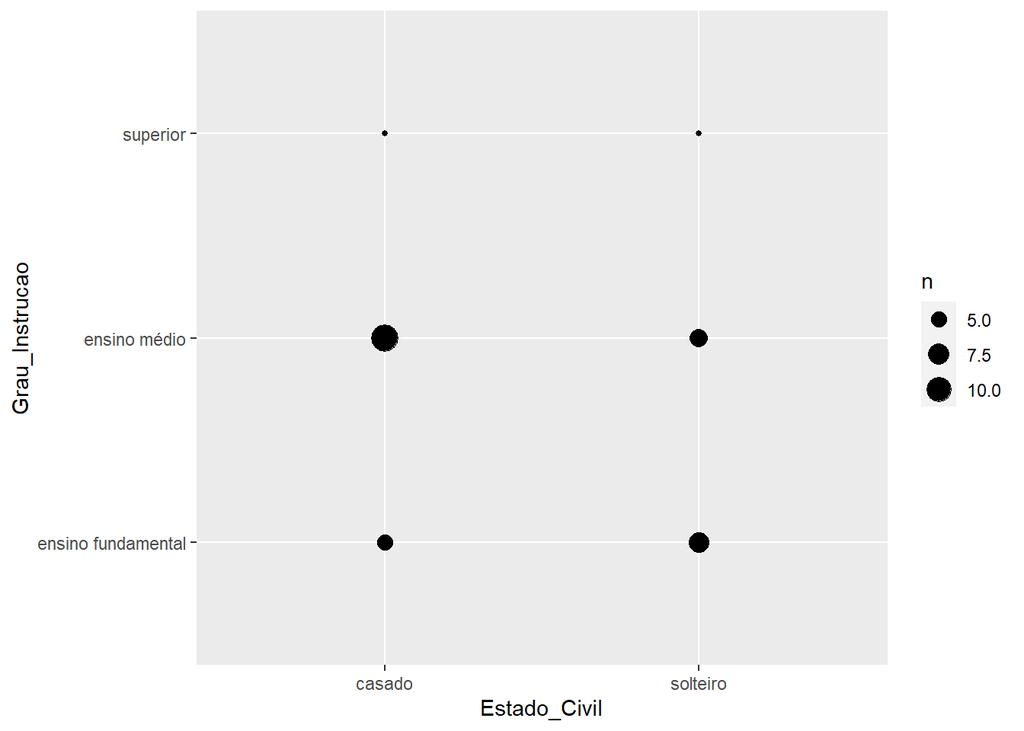

```r
ggplot(milsa, aes(x = Estado_Civil, y = Grau_Instrucao)) + geom_count()
```

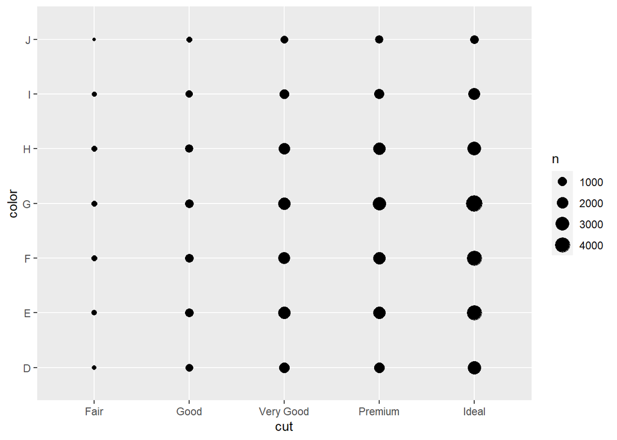

```r
ggplot(diamonds, aes(x = cut, y = color)) + geom_count()
```

O tamanho de cada círculo no gráfico exibe quantas observações ocorreram em cada combinação de valores. A covariação aparecerá como uma forte correlação entre valores específicos de x e valores específicos de y.

Outra abordagem é calcular a contagem e em seguida, visualize com `geom_tile()` e a estética de preenchimento:

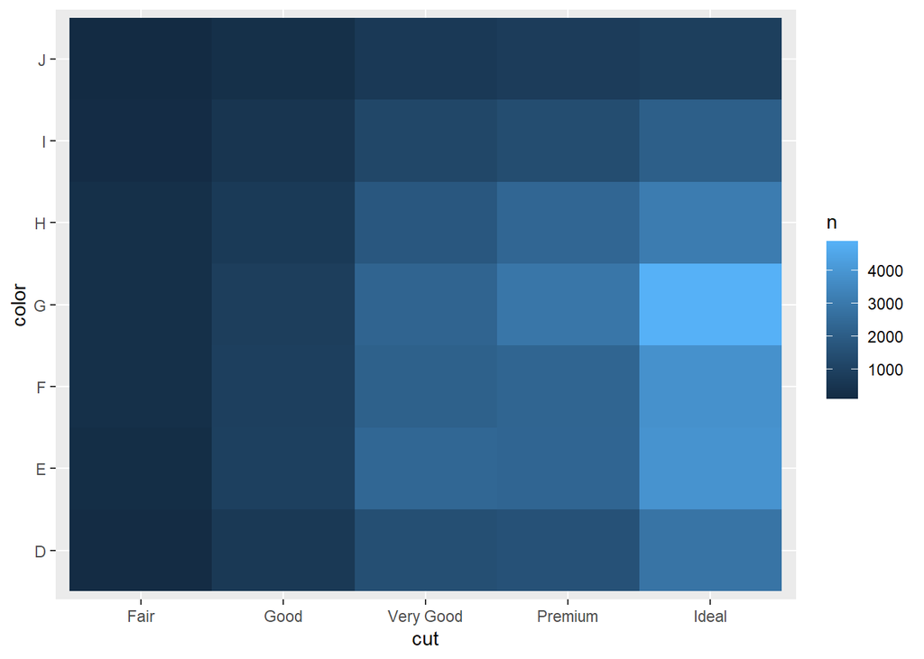

```r
data = count(diamonds, color, cut)
ggplot(data, aes(x = cut, y = color)) + geom_tile(aes(fill = n))
```

## 3.2 Qualitativa vs Quantitativa

Para exemplificar este caso vamos considerar as variáveis `Grau.de.Instrucao` e `Salario`.

É comum querer explorar a distribuição de uma variável contínua decomposta por uma variável categórica.

No gráfico vamos considerar que neste exemplo a instrução deve ser a variável explicativa e portanto colocada no eixo X, e o salário é a variável resposta, e portanto deve ser colocada no eixo Y. Isto é, consideramos que a instrução deve explicar, ainda que parcialmente, o salário (e não o contrário!).

Vamos então obter um boxplot dos salários para cada nível de instrução.

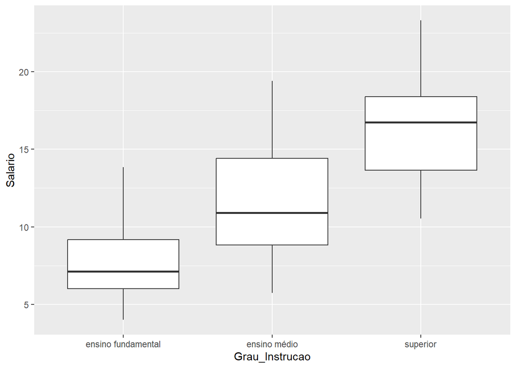

```r
ggplot(milsa, aes(x = Grau_Instrucao, y = Salario)) + geom_boxplot()
```